The format of this lab follows the same format as the previous ones. Your goal is to predict the value of the third column (which will be missing on the test set) using the techniques we have learned so far.

# Set-up

Read in the following libraries and to load the metadata:

```r
library(readr)
library(dplyr)
```

```r
library(ggplot2)
library(viridis)
library(stringi)
library(tokenizers)
library(smodels)
library(keras)
library(Matrix)
library(methods)

amazon <- read_csv("https://statsmaths.github.io/ml_data/amazon_product_stars.csv")
```

# Lab 23

Let us start by first constructing the data sets we will pass into our LSTM RNN model.

```r
words <- tokenize_words(amazon$text)
vocab <- top_n(count(data_frame(word = unlist(words)), word), n=5000)$word
id <- lapply(words, function(v) match(v, vocab))
id <- lapply(id, function(v) v[!is.na(v)])
X <- pad_sequences(id, maxlen = 100)
y <- amazon$positive

X_train <- X[amazon$train_id == "train",]
X_valid <- X[amazon$train_id == "valid",]
y_train <- to_categorical(y[amazon$train_id == "train"], num_classes = 2)
y_valid <- to_categorical(y[amazon$train_id == "valid"], num_classes = 2)
```

Next, lets build the model. I found that the lstm layer would require a lower number of units to generate a more stable valid state. I also played around with the dropout rates but 0.2 seemed to provide the most stability and best valid rates so I stuck with this model. I also only used a few epochs since my validation rate would decay quite substantially after 5 or more epochs. I also decided to reduce my recurrent dropout due to noise, this also helped reduce the degree of overfitting.

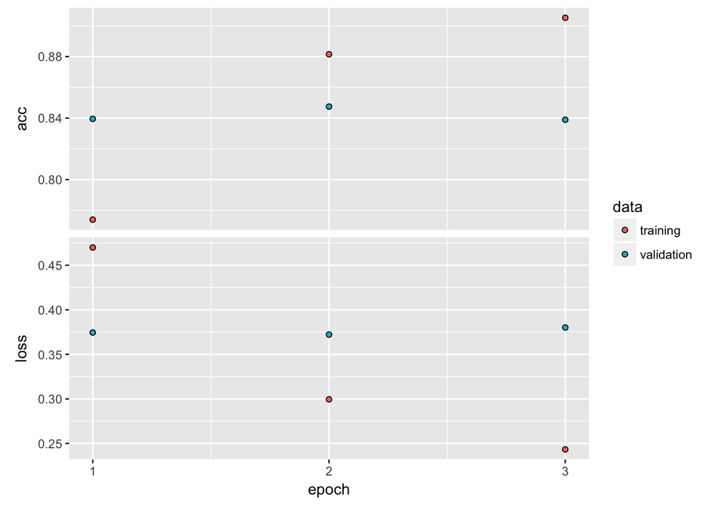

```r
model <- keras_model_sequential()
model %>%
  layer_embedding(input_dim = length(vocab) + 1,
                  output_dim = 128,
                  input_length = ncol(X)) %>%

  layer_lstm(units = 32,
             dropout = 0.2,
             recurrent_dropout = 0.1,
             return_sequences = FALSE) %>%
  layer_dense(units = 2, activation = 'softmax')

model %>% compile(loss = 'binary_crossentropy',
                  optimizer = 'adam',
                  metrics = c('accuracy'))

history <- model %>% fit(X_train, y_train,

                         epochs = 3,
                         validation_data = list(X_valid, y_valid))

plot(history)
```

Below we see our prediction results.

```r
 y_pred <- predict_classes(model, X)
tapply(y_pred == amazon$positive, amazon$train_id, mean)
```

```
##      test     train     valid
##        NA 0.9448871 0.8389300
```

# Submission

The code below assumes that you have added a prediction named `class_pred` to every row of the dataset.

```r
amazon$class_pred <- y_pred
submit <- select(amazon, obs_id, class_pred)
write_csv(submit, "class23_submit.csv")
```

Now, upload this file (ends with “.Rmd”), the HTML output (ends with “.nb.html” or “.html”), and the csv file to GitHub.